# CMPINF 2130 Summer 2021 - Week 10

Working with linear models

Dr. Joseph P. Yurko

7/19/2021

## Load packages

We will use `tidyverse`, base `R`, and `coefplot`, and `broom`.

```r
library(tidyverse)
```

```r
library(coefplot)
```

## Read data

```r
data_url <- "https://raw.githubusercontent.com/DanielTongAwesome/Yacht_Hydrodynamics_Model/master/yacht_hydrodynamics.data"

yacht <- readr::read_delim(data_url, delim = " ", col_names = FALSE)
```

## Clean data

```r
yacht <- yacht %>% mutate(X2 = as.numeric(X2))

yacht <- yacht %>% rename(y = X7)
```

Check with a summary.

```r
yacht %>% summary()
```

```
##        X1               X2               X3              X4
##  Min.   :-5.000   Min.   :0.5300   Min.   :4.340   Min.   :2.810
##  1st Qu.:-2.400   1st Qu.:0.5460   1st Qu.:4.770   1st Qu.:3.750
##  Median :-2.300   Median :0.5650   Median :4.780   Median :3.955
##  Mean   :-2.382   Mean   :0.5641   Mean   :4.789   Mean   :3.937
##  3rd Qu.:-2.300   3rd Qu.:0.5740   3rd Qu.:5.100   3rd Qu.:4.170
##  Max.   : 0.000   Max.   :0.6000   Max.   :5.140   Max.   :5.350
##        X5              X6               y
##  Min.   :2.730   Min.   :0.1250   Min.   : 0.0100
##  1st Qu.:3.150   1st Qu.:0.2000   1st Qu.: 0.7775
##  Median :3.150   Median :0.2875   Median : 3.0650
##  Mean   :3.207   Mean   :0.2875   Mean   :10.4954
##  3rd Qu.:3.510   3rd Qu.:0.3750   3rd Qu.:12.8150
##  Max.   :3.640   Max.   :0.4500   Max.   :62.4200
```

## Preprocess

Log transform the response, standardize all variables in the data.

```r
ready_df <- yacht %>%
  mutate(log_y = log(y)) %>%
  select(X1:X6, log_y) %>%
  scale(center = TRUE, scale = TRUE) %>%
  as.data.frame() %>% tibble::as_tibble()

ready_df %>% glimpse()
```

```
## Rows: 308
## Columns: 7
## $ X1    <dbl> 0.05406897, 0.05406897, 0.05406897, 0.05406897, 0.05406897, 0.05~
## $ X2    <dbl> 0.1658925, 0.1658925, 0.1658925, 0.1658925, 0.1658925, 0.1658925~
## $ X3    <dbl> -0.03412813, -0.03412813, -0.03412813, -0.03412813, -0.03412813,~
## $ X4    <dbl> 0.09701294, 0.09701294, 0.09701294, 0.09701294, 0.09701294, 0.09~
## $ X5    <dbl> -0.1484614, -0.1484614, -0.1484614, -0.1484614, -0.1484614, -0.1~
## $ X6    <dbl> -1.6098318, -1.3621654, -1.1144989, -0.8668325, -0.6191661, -0.3~
## $ log_y <dbl> -1.78118026, -1.29530409, -0.99536657, -0.72126630, -0.49726401,~
```

Let’s check by calculating the mean and variance per column.

```r
ready_df %>% purrr::map_dbl(mean)
```

```
##            X1            X2            X3            X4            X5
##  8.769350e-17 -1.743993e-15 -1.568862e-15 -2.447175e-16  5.817505e-16
##            X6         log_y
##  2.300670e-16  2.574839e-17
```

```r
ready_df %>% purrr::map_dbl(var)
```

```
##    X1    X2    X3    X4    X5    X6 log_y
##     1     1     1     1     1     1     1
```

Check the variables with a scatter plot of the response vs each input.

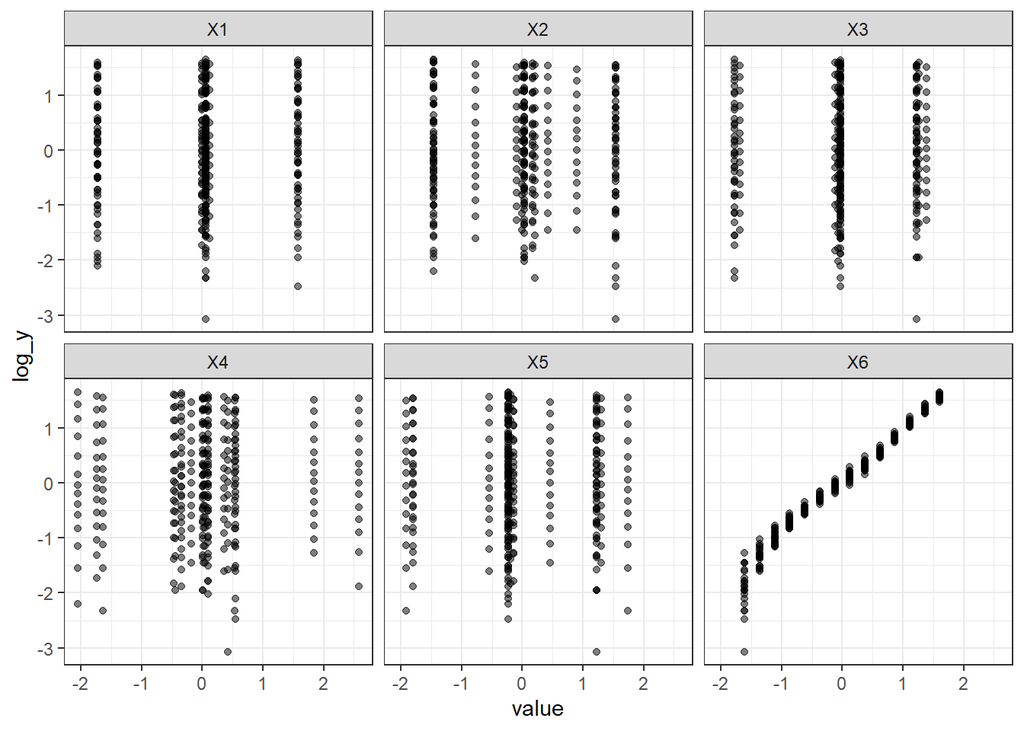

```r
ready_df %>%
  tibble::rowid_to_column() %>%
  pivot_longer(starts_with("X")) %>%
  ggplot(mapping = aes(x = value, y = log_y)) +
  geom_point(alpha = 0.5) +
  facet_wrap(~name) +
  theme_bw()
```

## Linear models

### Linear additive terms

The conventional “linear regression” model.

```r
fit_a <- lm( log_y ~ ., data = ready_df)
```

Summarize the model with `summary()`.

```r
fit_a %>% summary()
```

```
##
## Call:
## lm(formula = log_y ~ ., data = ready_df)
##
## Residuals:
##      Min       1Q   Median       3Q      Max
## -1.47597 -0.05678  0.00730  0.10292  0.30363
##
## Coefficients:
##               Estimate Std. Error t value Pr(>|t|)
## (Intercept)  2.826e-16  9.727e-03   0.000    1.000
## X1           1.766e-02  9.747e-03   1.812    0.071 .
## X2          -7.829e-03  1.959e-02  -0.400    0.690
## X3           6.365e-02  6.830e-02   0.932    0.352
## X4          -1.968e-02  5.767e-02  -0.341    0.733
## X5          -6.227e-02  6.709e-02  -0.928    0.354
## X6           9.848e-01  9.743e-03 101.087   <2e-16 ***
## ---
## Signif. codes:  0 '***' 0.001 '**' 0.01 '*' 0.05 '.' 0.1 ' ' 1
##
## Residual standard error: 0.1707 on 301 degrees of freedom
## Multiple R-squared:  0.9714, Adjusted R-squared:  0.9709
## F-statistic:  1706 on 6 and 301 DF,  p-value: < 2.2e-16
```

Use `coefplot()` to visualize the coefficient summaries for the model.

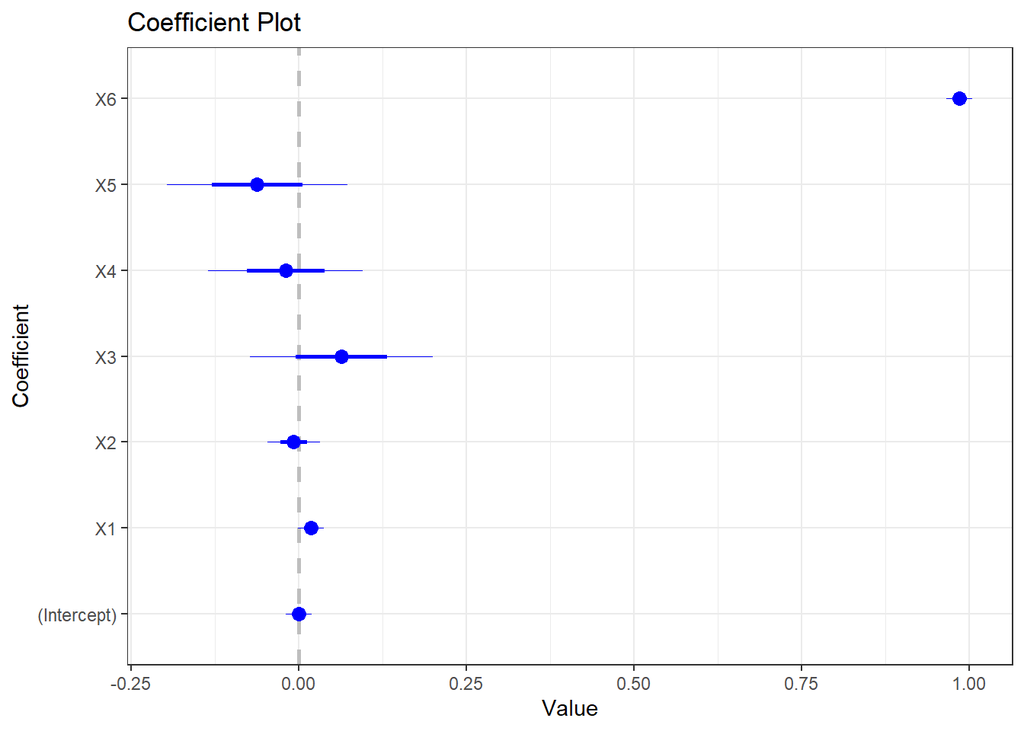

```r
fit_a %>% coefplot() + theme_bw() +
  guides(color = 'none', linetype = 'none', shape='none')
```

### All-pair-wise interactions

```r
fit_b <- lm( log_y ~ (.)^2, data = ready_df)
```

Print the summary.

```r
fit_b %>% summary()
```

```
##
## Call:
## lm(formula = log_y ~ (.)^2, data = ready_df)
##
## Residuals:
##      Min       1Q   Median       3Q      Max
## -1.38214 -0.06383  0.01966  0.09515  0.27256
##
## Coefficients:
##              Estimate Std. Error t value Pr(>|t|)
## (Intercept)  0.046593   0.023162   2.012   0.0452 *
## X1           0.046961   0.075660   0.621   0.5353
## X2          -0.117928   0.057172  -2.063   0.0400 *
## X3          -0.334736   0.211281  -1.584   0.1142
## X4           0.342209   0.191958   1.783   0.0757 .
## X5           0.307012   0.201262   1.525   0.1283
## X6           0.984840   0.009563 102.983   <2e-16 ***
## X1:X2        0.211830   0.335947   0.631   0.5288
## X1:X3        0.175917   0.759077   0.232   0.8169
## X1:X4       -0.726554   1.129865  -0.643   0.5207
## X1:X5       -0.208674   0.728240  -0.287   0.7747
## X1:X6       -0.002597   0.009583  -0.271   0.7866
## X2:X3       -0.019086   0.058715  -0.325   0.7454
## X2:X4       -0.051153   0.035246  -1.451   0.1478
## X2:X5        0.006820   0.058054   0.117   0.9066
## X2:X6        0.031239   0.019265   1.622   0.1060
## X3:X4       -0.001246   0.018956  -0.066   0.9476
## X3:X5       -0.004149   0.012469  -0.333   0.7396
## X3:X6        0.017410   0.067147   0.259   0.7956
## X4:X5        0.059643   0.026834   2.223   0.0270 *
## X4:X6       -0.044096   0.056696  -0.778   0.4374
## X5:X6       -0.014070   0.065967  -0.213   0.8313
## ---
## Signif. codes:  0 '***' 0.001 '**' 0.01 '*' 0.05 '.' 0.1 ' ' 1
##
## Residual standard error: 0.1676 on 286 degrees of freedom
## Multiple R-squared:  0.9738, Adjusted R-squared:  0.9719
## F-statistic: 507.1 on 21 and 286 DF,  p-value: < 2.2e-16
```

Visualize the coefficient summaries.

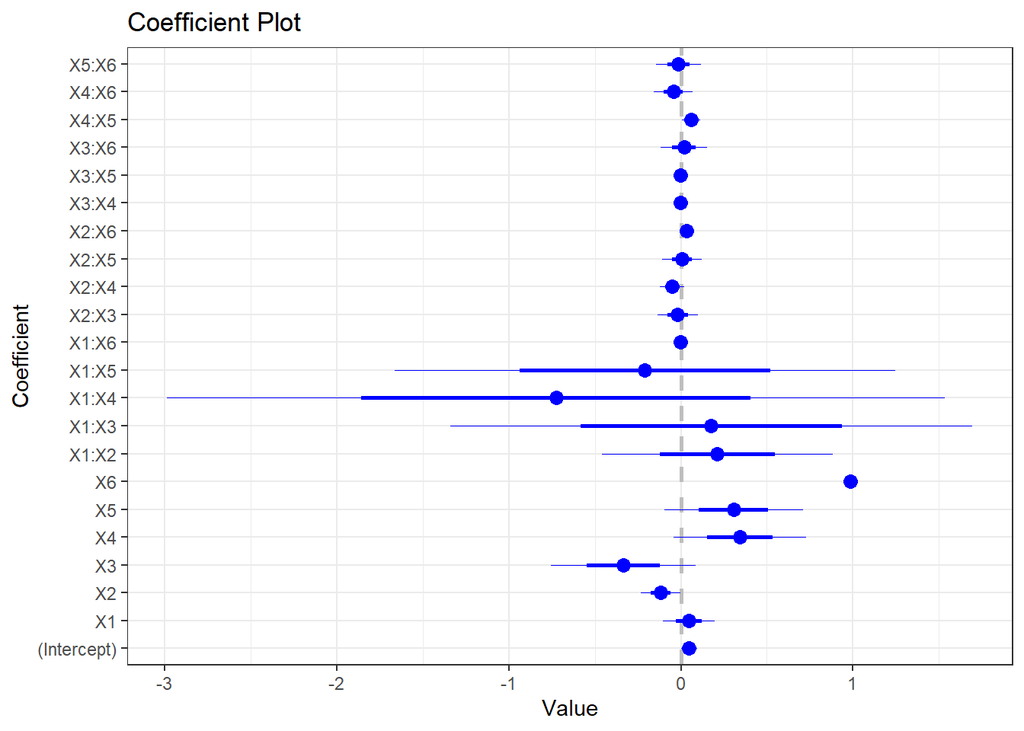

```r
fit_b %>%
  coefplot() +
  theme_bw() +
  guides(color = 'none', linetype = 'none', shape='none')
```

The `coefplot` allows us to directly compare coefficients across models.

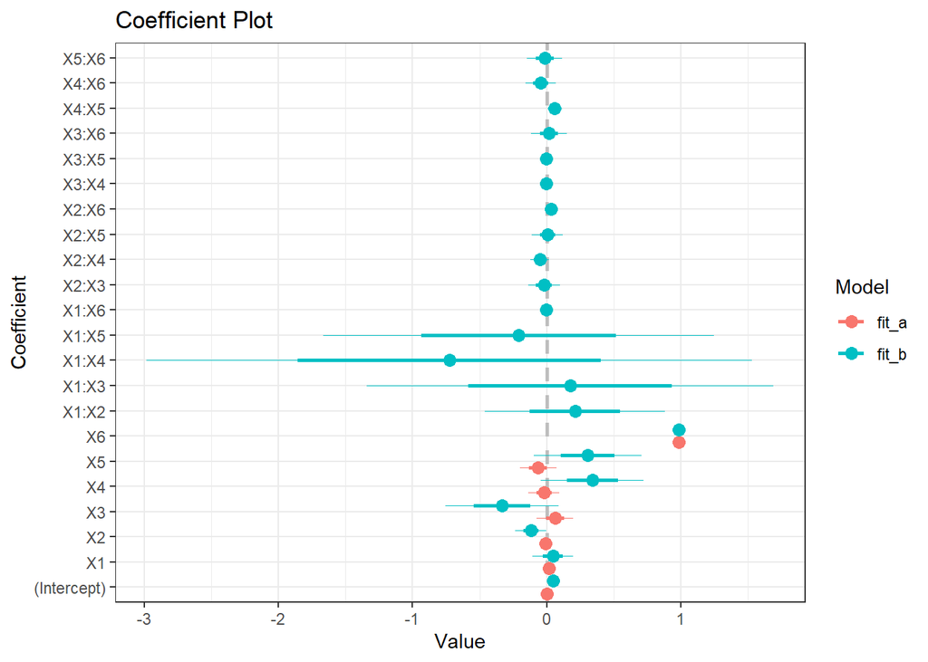

```r
coefplot::multiplot(fit_a, fit_b) + theme_bw() +
  guides(linetype = 'none', shape='none')
```

### Triplet interactions

```r
fit_c <- lm( log_y ~ (.)^3, data = ready_df)
```

But check the summary…

```r
fit_c %>% summary()
```

```
##
## Call:
## lm(formula = log_y ~ (.)^3, data = ready_df)
##
## Residuals:
##      Min       1Q   Median       3Q      Max
## -1.20822 -0.05773  0.01073  0.08473  0.30958
##
## Coefficients: (4 not defined because of singularities)
##               Estimate Std. Error t value Pr(>|t|)
## (Intercept) -1.993e-01  3.859e+00  -0.052 0.958837
## X1           3.277e+00  6.863e+01   0.048 0.961954
## X2           5.622e-01  1.607e+01   0.035 0.972112
## X3           1.361e+00  5.085e+01   0.027 0.978666
## X4          -9.927e-01  4.355e+01  -0.023 0.981833
## X5          -1.711e+00  4.950e+01  -0.035 0.972461
## X6           9.154e-01  2.165e-02  42.287  < 2e-16 ***
## X1:X2       -9.886e+00  2.917e+02  -0.034 0.972988
## X1:X3       -3.630e+01  9.385e+02  -0.039 0.969173
## X1:X4        2.414e+01  7.926e+02   0.030 0.975729
## X1:X5        3.504e+01  8.977e+02   0.039 0.968895
## X1:X6       -5.613e-02  7.072e-02  -0.794 0.428011
## X2:X3        4.707e-01  6.755e+00   0.070 0.944500
## X2:X4       -9.534e-02  2.532e+00  -0.038 0.969996
## X2:X5        1.131e+00  1.333e+01   0.085 0.932416
## X2:X6        2.154e-01  5.344e-02   4.030 7.25e-05 ***
## X3:X4        1.871e-01  6.028e-01   0.310 0.756538
## X3:X5        3.607e-01  8.379e-01   0.430 0.667229
## X3:X6        6.819e-01  1.975e-01   3.453 0.000643 ***
## X4:X5        9.337e-02  6.252e-02   1.493 0.136502
## X4:X6       -6.389e-01  1.794e-01  -3.561 0.000437 ***
## X5:X6       -6.370e-01  1.881e-01  -3.386 0.000813 ***
## X1:X2:X3    -1.845e+01  1.269e+02  -0.145 0.884487
## X1:X2:X4     1.842e+00  4.416e+01   0.042 0.966762
## X1:X2:X5    -8.110e+00  2.403e+02  -0.034 0.973102
## X1:X2:X6    -2.023e-01  3.140e-01  -0.644 0.519942
## X1:X3:X4            NA         NA      NA       NA
## X1:X3:X5            NA         NA      NA       NA
## X1:X3:X6    -6.869e-03  7.095e-01  -0.010 0.992282
## X1:X4:X5            NA         NA      NA       NA
## X1:X4:X6     7.090e-01  1.056e+00   0.671 0.502571
## X1:X5:X6     5.596e-02  6.807e-01   0.082 0.934535
## X2:X3:X4     8.460e-02  7.349e-01   0.115 0.908431
## X2:X3:X5    -2.839e-01  5.211e-01  -0.545 0.586358
## X2:X3:X6     3.073e-02  5.488e-02   0.560 0.575914
## X2:X4:X5    -1.802e-01  6.742e-01  -0.267 0.789474
## X2:X4:X6     8.692e-02  3.294e-02   2.638 0.008811 **
## X2:X5:X6     1.077e-03  5.426e-02   0.020 0.984174
## X3:X4:X5            NA         NA      NA       NA
## X3:X4:X6     1.917e-03  1.772e-02   0.108 0.913924
## X3:X5:X6    -7.302e-04  1.165e-02  -0.063 0.950091
## X4:X5:X6    -9.930e-02  2.508e-02  -3.959 9.63e-05 ***
## ---
## Signif. codes:  0 '***' 0.001 '**' 0.01 '*' 0.05 '.' 0.1 ' ' 1
##
## Residual standard error: 0.1564 on 270 degrees of freedom
## Multiple R-squared:  0.9785, Adjusted R-squared:  0.9756
## F-statistic: 332.1 on 37 and 270 DF,  p-value: < 2.2e-16
```

### non-linear trends

Try a model with cubic trend with respect to `X6`.

```r
fit_d <- lm( log_y ~ (.) + I(X6^2) + I(X6^3), data = ready_df)
```

Check the summary.

```r
fit_d %>% summary()
```

```
##
## Call:
## lm(formula = log_y ~ (.) + I(X6^2) + I(X6^3), data = ready_df)
##
## Residuals:
##      Min       1Q   Median       3Q      Max
## -1.22015 -0.05218 -0.00006  0.05515  0.50270
##
## Coefficients:
##              Estimate Std. Error t value Pr(>|t|)
## (Intercept)  0.069386   0.011546   6.009 5.41e-09 ***
## X1           0.017662   0.007680   2.300   0.0222 *
## X2          -0.007829   0.015440  -0.507   0.6125
## X3           0.063647   0.053814   1.183   0.2379
## X4          -0.019683   0.045439  -0.433   0.6652
## X5          -0.062271   0.052868  -1.178   0.2398
## X6           0.786893   0.019548  40.253  < 2e-16 ***
## I(X6^2)     -0.069612   0.008664  -8.035 2.19e-14 ***
## I(X6^3)      0.111089   0.010089  11.011  < 2e-16 ***
## ---
## Signif. codes:  0 '***' 0.001 '**' 0.01 '*' 0.05 '.' 0.1 ' ' 1
##
## Residual standard error: 0.1345 on 299 degrees of freedom
## Multiple R-squared:  0.9824, Adjusted R-squared:  0.9819
## F-statistic:  2084 on 8 and 299 DF,  p-value: < 2.2e-16
```

Visualize the coefficient summaries.

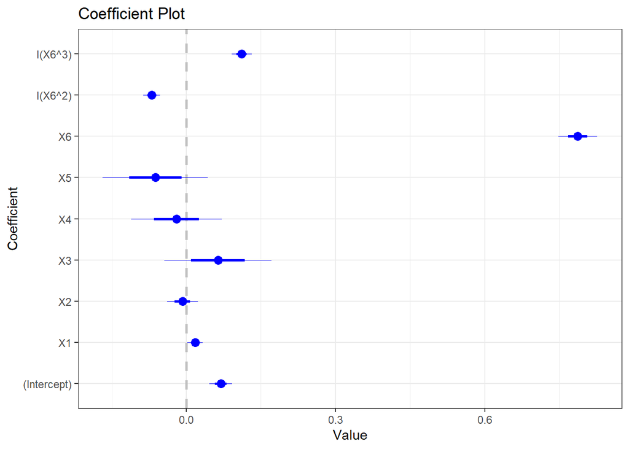

```r
fit_d %>%
  coefplot() +
  theme_bw() +
  guides(color = 'none', linetype = 'none', shape='none')
```

### More models

```r
fit_e <- lm( log_y ~ (X1 + X2 + X3 + X4 + X5) * splines::ns(X6, 5), data = ready_df)
```

```r
fit_e %>% summary()
```

```
##
## Call:
## lm(formula = log_y ~ (X1 + X2 + X3 + X4 + X5) * splines::ns(X6,
##     5), data = ready_df)
##
## Residuals:
##      Min       1Q   Median       3Q      Max
## -0.89555 -0.03322 -0.00281  0.03037  0.63063
##
## Coefficients:
##                         Estimate Std. Error t value Pr(>|t|)
## (Intercept)            -1.883202   0.022806 -82.574  < 2e-16 ***
## X1                      0.016251   0.022853   0.711 0.477622
## X2                     -0.168361   0.045944  -3.664 0.000298 ***
## X3                      0.043261   0.160132   0.270 0.787245
## X4                      0.051424   0.135209   0.380 0.703997
## X5                     -0.095423   0.157317  -0.607 0.544647
## splines::ns(X6, 5)1     1.616901   0.037235  43.424  < 2e-16 ***
## splines::ns(X6, 5)2     2.171317   0.043224  50.234  < 2e-16 ***
## splines::ns(X6, 5)3     2.612612   0.035283  74.048  < 2e-16 ***
## splines::ns(X6, 5)4     4.213865   0.058401  72.154  < 2e-16 ***
## splines::ns(X6, 5)5     2.780565   0.027726 100.287  < 2e-16 ***
## X1:splines::ns(X6, 5)1 -0.017366   0.037312  -0.465 0.641996
## X1:splines::ns(X6, 5)2 -0.001780   0.043313  -0.041 0.967250
## X1:splines::ns(X6, 5)3  0.008384   0.035356   0.237 0.812722
## X1:splines::ns(X6, 5)4  0.017726   0.058522   0.303 0.762203
## X1:splines::ns(X6, 5)5 -0.024560   0.027783  -0.884 0.377488
## X2:splines::ns(X6, 5)1  0.170895   0.075011   2.278 0.023487 *
## X2:splines::ns(X6, 5)2  0.297805   0.087076   3.420 0.000722 ***
## X2:splines::ns(X6, 5)3  0.083651   0.071078   1.177 0.240272
## X2:splines::ns(X6, 5)4  0.278718   0.117652   2.369 0.018535 *
## X2:splines::ns(X6, 5)5  0.052493   0.055855   0.940 0.348154
## X3:splines::ns(X6, 5)1  0.033764   0.261443   0.129 0.897338
## X3:splines::ns(X6, 5)2  0.108335   0.303492   0.357 0.721398
## X3:splines::ns(X6, 5)3  0.062388   0.247735   0.252 0.801361
## X3:splines::ns(X6, 5)4 -0.062852   0.410061  -0.153 0.878296
## X3:splines::ns(X6, 5)5  0.016045   0.194677   0.082 0.934374
## X4:splines::ns(X6, 5)1 -0.084961   0.220752  -0.385 0.700634
## X4:splines::ns(X6, 5)2 -0.132112   0.256257  -0.516 0.606591
## X4:splines::ns(X6, 5)3 -0.138358   0.209177  -0.661 0.508892
## X4:splines::ns(X6, 5)4 -0.073186   0.346239  -0.211 0.832753
## X4:splines::ns(X6, 5)5 -0.100985   0.164377  -0.614 0.539500
## X5:splines::ns(X6, 5)1  0.013178   0.256847   0.051 0.959119
## X5:splines::ns(X6, 5)2 -0.039235   0.298158  -0.132 0.895406
## X5:splines::ns(X6, 5)3 -0.033590   0.243380  -0.138 0.890330
## X5:splines::ns(X6, 5)4  0.189208   0.402853   0.470 0.638967
## X5:splines::ns(X6, 5)5 -0.028518   0.191255  -0.149 0.881576
## ---
## Signif. codes:  0 '***' 0.001 '**' 0.01 '*' 0.05 '.' 0.1 ' ' 1
##
## Residual standard error: 0.1167 on 272 degrees of freedom
## Multiple R-squared:  0.9879, Adjusted R-squared:  0.9864
## F-statistic: 636.7 on 35 and 272 DF,  p-value: < 2.2e-16
```

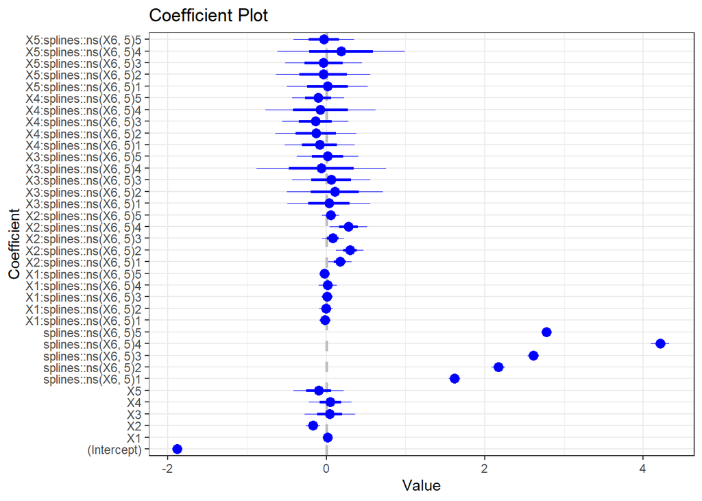

```r
fit_e %>%
  coefplot() +
  theme_bw() +
  guides(color = 'none', linetype = 'none', shape='none')
```

One more model.

```r
fit_f <- lm( log_y ~ (X1 + X4) * (X2 + X3 + X5 + splines::ns(X6, 5)), data = ready_df)
```

```r
fit_f %>% summary()
```

```
##
## Call:
## lm(formula = log_y ~ (X1 + X4) * (X2 + X3 + X5 + splines::ns(X6,
##     5)), data = ready_df)
##
## Residuals:
##      Min       1Q   Median       3Q      Max
## -1.16658 -0.04961 -0.00430  0.04008  0.47151
##
## Coefficients:
##                         Estimate Std. Error t value Pr(>|t|)
## (Intercept)            -1.844396   0.026745 -68.963  < 2e-16 ***
## X1                      0.042664   0.057985   0.736  0.46248
## X4                      0.271307   0.117725   2.305  0.02192 *
## X2                     -0.092076   0.035544  -2.590  0.01009 *
## X3                     -0.248904   0.134995  -1.844  0.06627 .
## X5                      0.225213   0.128511   1.752  0.08078 .
## splines::ns(X6, 5)1     1.616901   0.039661  40.768  < 2e-16 ***
## splines::ns(X6, 5)2     2.171317   0.046040  47.162  < 2e-16 ***
## splines::ns(X6, 5)3     2.612612   0.037581  69.519  < 2e-16 ***
## splines::ns(X6, 5)4     4.213865   0.062206  67.741  < 2e-16 ***
## splines::ns(X6, 5)5     2.780565   0.029532  94.153  < 2e-16 ***
## X1:X2                  -0.004231   0.006676  -0.634  0.52682
## X1:X3                  -0.155507   0.340741  -0.456  0.64847
## X1:X5                   0.131828   0.300053   0.439  0.66075
## X1:splines::ns(X6, 5)1 -0.019165   0.039725  -0.482  0.62988
## X1:splines::ns(X6, 5)2 -0.004961   0.046115  -0.108  0.91440
## X1:splines::ns(X6, 5)3  0.007421   0.037642   0.197  0.84386
## X1:splines::ns(X6, 5)4  0.014859   0.062307   0.238  0.81168
## X1:splines::ns(X6, 5)5 -0.025060   0.029581  -0.847  0.39761
## X4:X2                  -0.050657   0.014083  -3.597  0.00038 ***
## X4:X3                  -0.007009   0.011376  -0.616  0.53829
## X4:X5                   0.050240   0.017735   2.833  0.00495 **
## X4:splines::ns(X6, 5)1 -0.019231   0.039725  -0.484  0.62869
## X4:splines::ns(X6, 5)2  0.024732   0.046115   0.536  0.59217
## X4:splines::ns(X6, 5)3 -0.073678   0.037642  -1.957  0.05130 .
## X4:splines::ns(X6, 5)4 -0.074189   0.062307  -1.191  0.23478
## X4:splines::ns(X6, 5)5 -0.066274   0.029581  -2.240  0.02584 *
## ---
## Signif. codes:  0 '***' 0.001 '**' 0.01 '*' 0.05 '.' 0.1 ' ' 1
##
## Residual standard error: 0.1243 on 281 degrees of freedom
## Multiple R-squared:  0.9859, Adjusted R-squared:  0.9846
## F-statistic: 753.8 on 26 and 281 DF,  p-value: < 2.2e-16
```

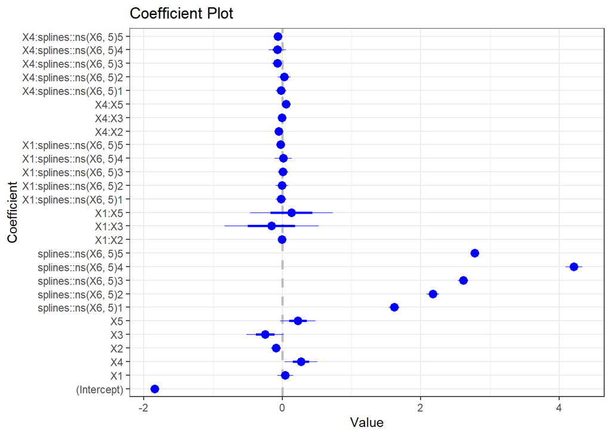

```r
fit_f %>%
  coefplot() +
  theme_bw() +
  guides(color = 'none', linetype = 'none', shape='none')
```

## Model selection

How do we select the best model?

Look at the model fits via **predicted vs observed** plot. Include the confidence interval.

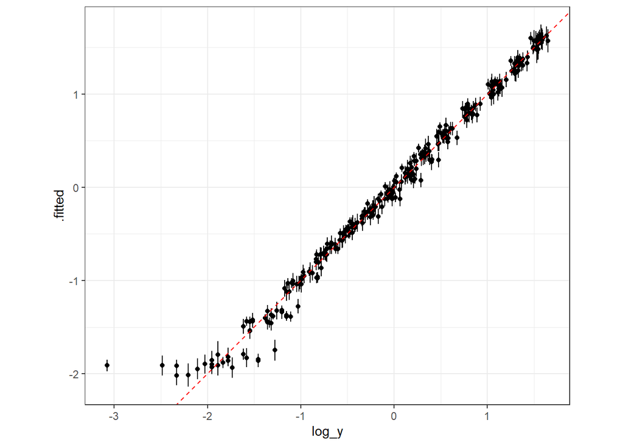

```r
fit_f %>%
  broom::augment(data = ready_df, se_fit = TRUE) %>%
  tibble::rowid_to_column() %>%
  ggplot(mapping = aes(x = log_y, y = .fitted)) +
  geom_linerange(mapping = aes(ymin = .fitted - 2*.se.fit,
                               ymax = .fitted + 2*.se.fit,
                               group = rowid)) +
  geom_point() +
  geom_abline(intercept = 0, slope = 1, linetype = 'dashed', color = 'red') +
  coord_equal() +
  theme_bw()
```

Include the **prediction interval** instead.

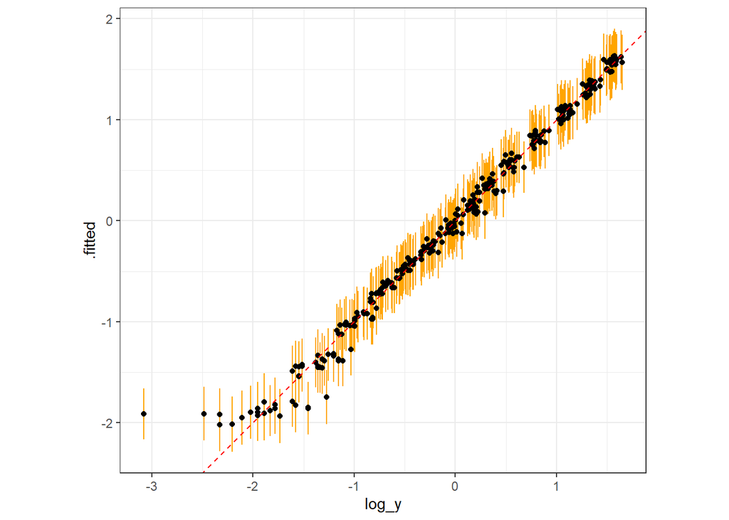

```r
fit_f %>%
  broom::augment(data = ready_df, se_fit = TRUE, interval = 'prediction') %>%
  tibble::rowid_to_column() %>%
  ggplot(mapping = aes(x = log_y, y = .fitted)) +
  geom_linerange(mapping = aes(ymin = .lower,
                               ymax = .upper,
                               group = rowid),
                 color = 'orange') +
  geom_point() +
  geom_abline(intercept = 0, slope = 1, linetype = 'dashed', color = 'red') +
  coord_equal() +
  theme_bw()
```

Predicted vs observed for a simpler model.

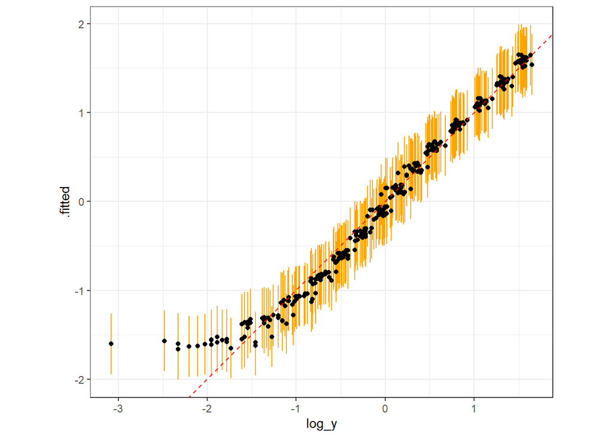

```r
fit_a %>%
  broom::augment(data = ready_df, se_fit = TRUE, interval = 'prediction') %>%
  tibble::rowid_to_column() %>%
  ggplot(mapping = aes(x = log_y, y = .fitted)) +
  geom_linerange(mapping = aes(ymin = .lower,
                               ymax = .upper,
                               group = rowid),
                 color = 'orange') +
  geom_point() +
  geom_abline(intercept = 0, slope = 1, linetype = 'dashed', color = 'red') +
  coord_equal() +
  theme_bw()
```

Combine the behavior of the two models.

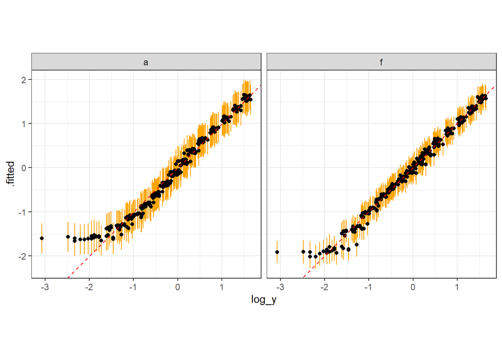

```r
fit_f %>%
  broom::augment(data = ready_df, se_fit = TRUE, interval = 'prediction') %>%
  tibble::rowid_to_column() %>%
  select(rowid, log_y, .fitted, .lower, .upper) %>%
  mutate(model_name = "f") %>%
  bind_rows(fit_a %>%
  broom::augment(data = ready_df, se_fit = TRUE, interval = 'prediction') %>%
  tibble::rowid_to_column() %>%
  select(rowid, log_y, .fitted, .lower, .upper) %>%
  mutate(model_name = "a")) %>%
  ggplot(mapping = aes(x = log_y, y = .fitted)) +
  geom_linerange(mapping = aes(ymin = .lower,
                               ymax = .upper,
                               group = interaction(rowid, model_name)),
                 color = 'orange') +
  geom_point() +
  geom_abline(intercept = 0, slope = 1, linetype = 'dashed', color = 'red') +
  facet_wrap(~model_name) +
  coord_equal() +
  theme_bw()
```

Let’s extract the R-squared for each model.

```r
extract_metrics <- function(mod, mod_name)
{
  broom::glance(mod) %>%
    mutate(model_name = mod_name)
}
```

Extract the performance metrics for each of the models.

```r
model_results <- purrr::map2_dfr(list(fit_a, fit_b, fit_d, fit_e, fit_f),
                                 c('a', 'b', 'd', 'e', 'f'),
                                 extract_metrics)
```

Check the structure.

```r
model_results %>% glimpse()
```

```
## Rows: 5
## Columns: 13
## $ r.squared     <dbl> 0.9714299, 0.9738442, 0.9823791, 0.9879407, 0.9858656
## $ adj.r.squared <dbl> 0.9708604, 0.9719237, 0.9819076, 0.9863890, 0.9845578
## $ sigma         <dbl> 0.1707032, 0.1675600, 0.1345078, 0.1166662, 0.1242665
## $ statistic     <dbl> 1705.7496, 507.0700, 2083.6866, 636.6654, 753.8322
## $ p.value       <dbl> 4.490728e-229, 1.489694e-212, 3.320727e-257, 4.863763e-2~
## $ df            <dbl> 6, 21, 8, 35, 26
## $ logLik        <dbl> 110.9986, 124.5950, 185.4229, 243.8279, 219.3764
## $ AIC           <dbl> -205.9972, -203.1901, -350.8458, -413.6557, -382.7527
## $ BIC           <dbl> -176.1564, -117.3978, -313.5448, -275.6420, -278.3099
## $ deviance      <dbl> 8.771014, 8.029835, 5.409614, 3.702191, 4.339247
## $ df.residual   <int> 301, 286, 299, 272, 281
## $ nobs          <int> 308, 308, 308, 308, 308
## $ model_name    <chr> "a", "b", "d", "e", "f"
```

Visualize R-squared for each model.

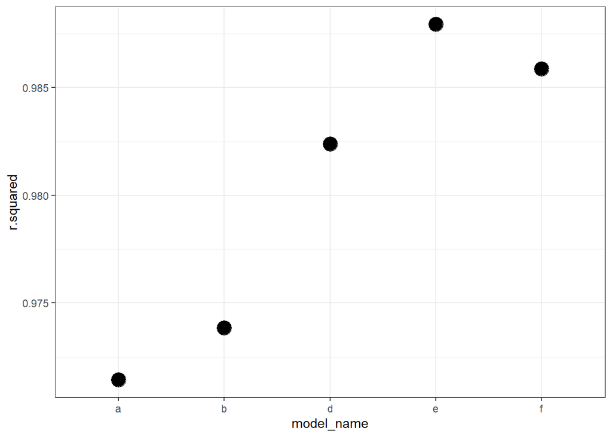

```r
model_results %>%
  ggplot(mapping = aes(x = model_name, y = r.squared)) +
  geom_point(size = 5.5) +
  theme_bw()
```

Look at the r-squared vs the degrees-of-freedom.

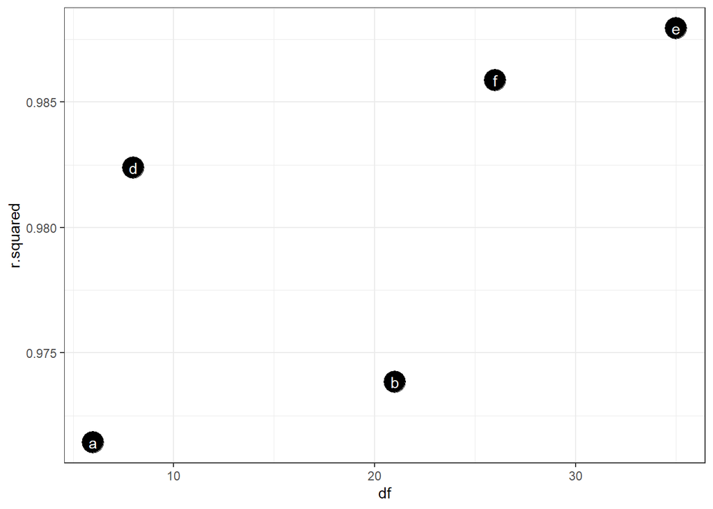

```r
model_results %>%
  ggplot(mapping = aes(x = df, y = r.squared)) +
  geom_point(size = 7) +
  geom_text(mapping = aes(label = model_name),
            color = 'white') +
  theme_bw()
```

AIC and BIC - information criterion - that penalize performance based on the number of parameters.

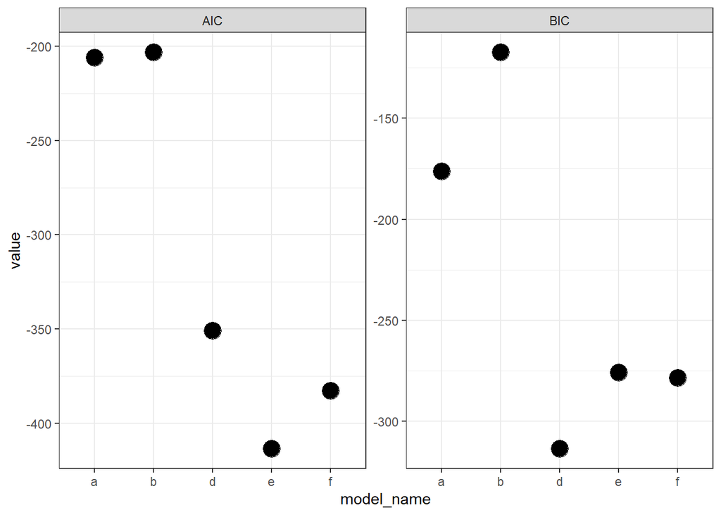

```r
model_results %>%
  select(model_name, AIC, BIC, df) %>%
  pivot_longer(c("AIC", "BIC")) %>%
  ggplot(mapping = aes(x = model_name, y = value)) +
  geom_point(size = 5.5) +
  facet_wrap(~name, scales = "free_y") +
  theme_bw()
```